# ecoforge_Rpackage example

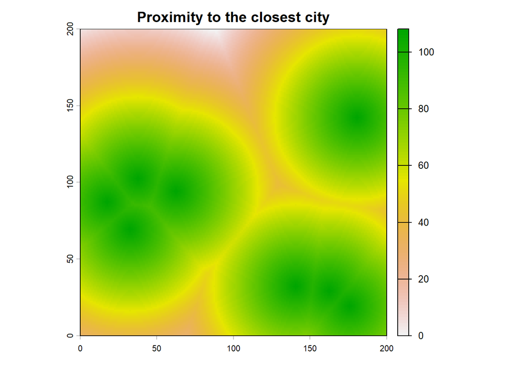

```r
#Calculate the inverse of the distance to obtain the proximity
interval_dist <- minmax(d.city_dots)
prox.city <- (d.city_dots*(-1)) + interval_dist[2,]
plot(prox.city, main="Proximity to the closest city", col= cols)
```

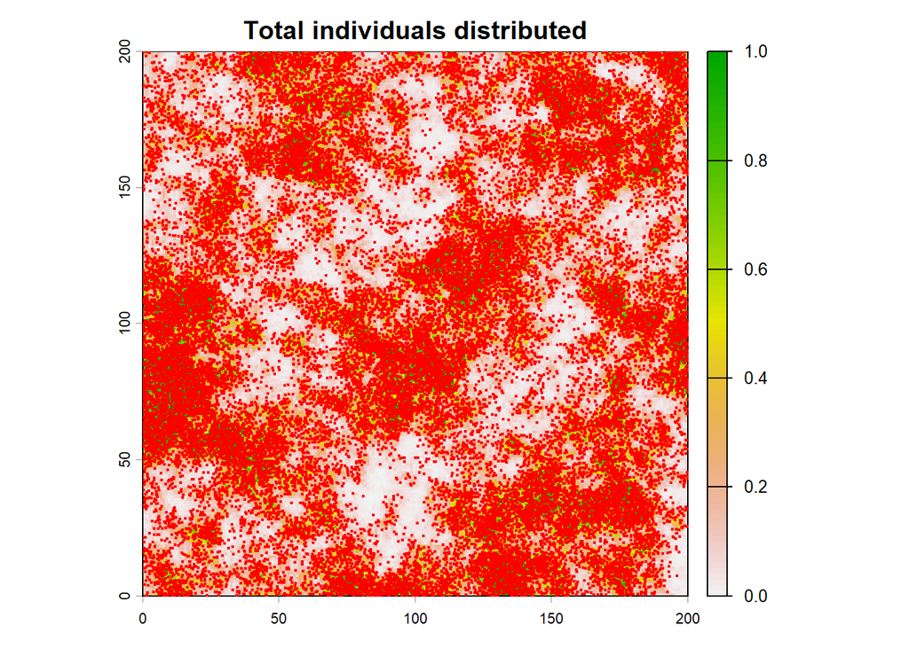

```r
#Calculate the probability of each individual to be selected based on the proximity to the city
v.occurssp <- vect(occurssp)
locs.prox_city <- extract(prox.city, v.occurssp, method = "simple")

#Select from the total of individuals distributed in the space, the percentage indicated (size) based on this proximity to the city (prob)
sampled <- sample(occurssp, size = n, prob = locs.prox_city$last)
xy <- data.frame(sampled@coords); names(xy) <- c("x", "y")
samp_ppp <- ppp(xy$x, xy$y, window = occurs$window)

#Visualize the difference between all the individuals and the percentage selected
plot(LAM_lgt_R, main="Total individuals distributed", col= cols)
points(occurs, cex = 0.3, pch=19, col='red')
```

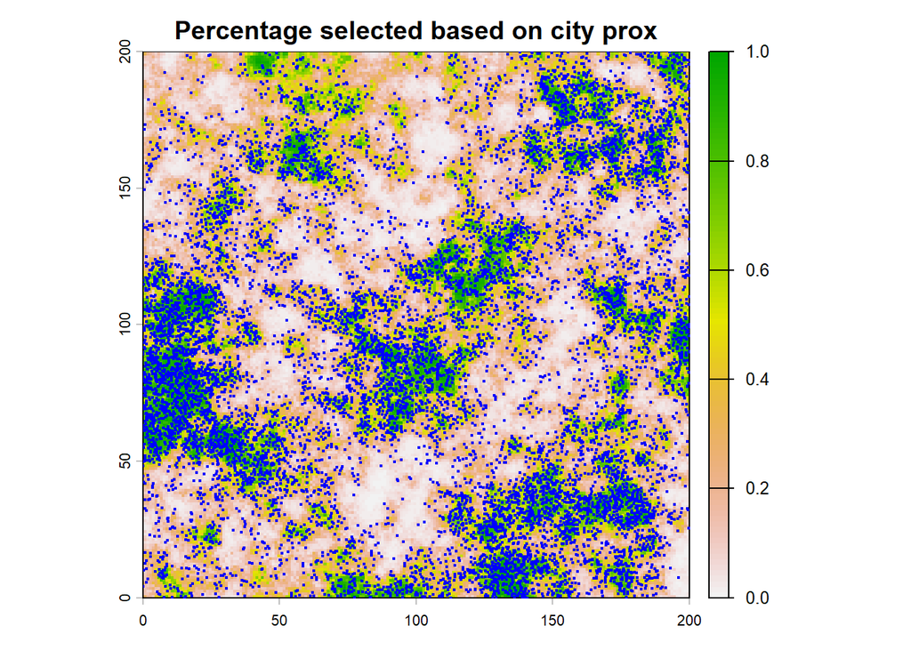

```r
plot(LAM_lgt_R, main="Percentage selected based on city prox", col= cols)
points(samp_ppp, cex = 0.3, pch=19, col='blue')
```

## 5. Sample the species’ distribution on the study area

In this section, we will determine the sampling points and prepare the databases we are going to use for subsequent analyses. To do this, we start by assigning the points in our study area where samples are to be taken.

### 5.1 Determine the grid for sampling

To do this, we have the function `randomSamp()` that allows us to define the area to be sampled `xrange & yrange`, the number of samples `n` and the resolution `cellsize` (minimum distance between sample points). From this grid, the function will randomly select the location of samples (based on the number of samples that we have specified) from all available points.

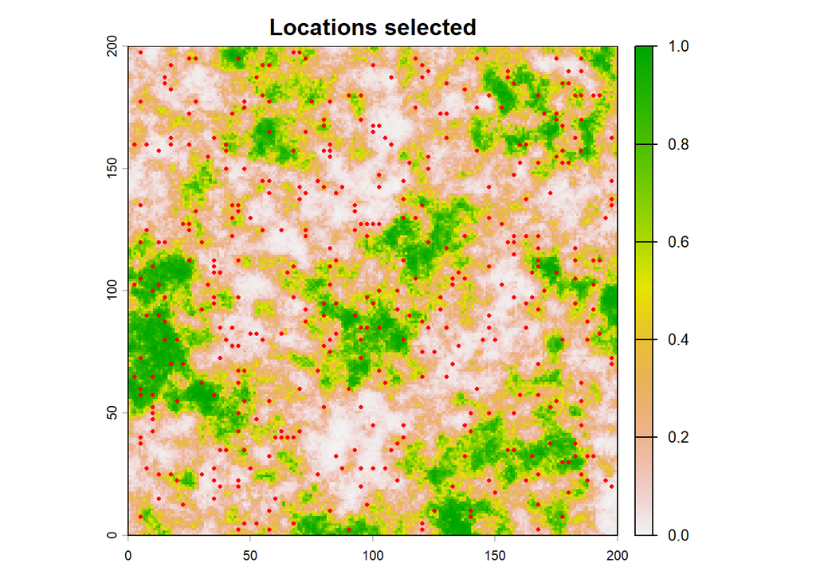

```r
#In this case we select a total of 400 locations, with a grid of 200 x 200 units and with a distance between points of 5 units (cellsize)
sam_units <- randomSamp(n= 400, xrange = c(0,200), yrange = c(0,200), cellsize = 5)

#Visualize the locations selected
plot(LAM_lgt_R, main= "Locations selected", col= cols)
points(sam_units, col='red', pch=16, cex=0.5)
```

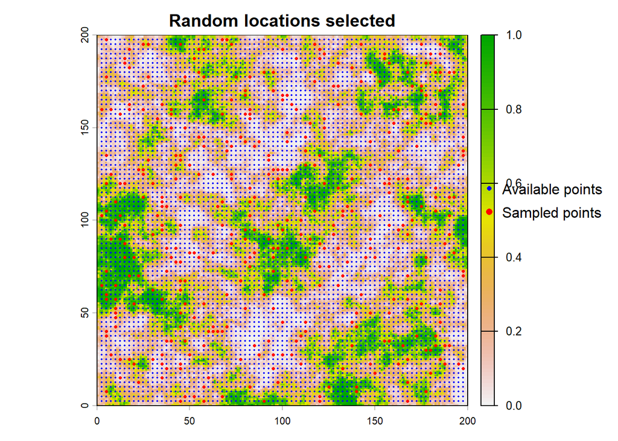

```r
#This is optional, but we can obtain the grid structure used to select the sampled points
  #Create our grid employed on the loc sampling selection
sam_grid <- uniformSamp(xrange = c(0,200), yrange = c(0,200), cellsize = 5)

#Visualize the grid and the sampling units selected
plot(LAM_lgt_R, main= "Random locations selected", col= cols)
points(sam_grid, col='blue', pch=16, cex=0.3)
points(sam_units, col='red', pch=16, cex=0.5)

#Add the legend
legend("topright", inset = c(-0.16, 0.35),
       legend = c("Available points", "Sampled points"),
       col = c("blue", "red"), pch = 16, pt.cex = c(0.7, 1),
       bty = "n", xpd = TRUE)
```

Although sampling can sometimes be uniform, such as with a camera trap grid. That is why we have the `uniformSamp()` function, which allows us to set this uniform sampling by specifying the area to be sampled `xrange & yrange`, and the resolution `cellsize`.

[figure not shown]

```r
#Create our grid employed on the loc sampling selection
uniform_grid <- uniformSamp(xrange = c(0,200), yrange = c(0,200), cellsize = 40)

#Visualize the grid and the sampling units selected
plot(LAM_lgt_R, main= "Uniform locations selected", col= cols)
points(uniform_grid, col='red', pch=16, cex=0.5)
```

### 5.2 Data collection (Abundance values)

Once we have determined the sampling points, we move on to collecting the data itself. In this case, data collection can be done in two different ways: as fixed points or as transects.

#### 5.2.1 Point Sampling Method

For this type of sampling, we have the `pointSample()` function, which allows us to collect information from each unit as a fixed point (for example, as if it were a camera trap or fixed observation points). With this function, you must specify the points you want to sample `sites`, the location of the individuals to be sampled `occ`, and the detection radius `radius`. The function saves a matrix with the individuals as rows and the sampling units as columns, assigning the Euclidean distance from each individual to each sampling unit if it is less than the detection range.

```r
#Pass the occurrences to dataframe
occus <- data.frame(occurs$x, occurs$y)

#Obtain the individual locations (with euclidean distance) for all the sampled points used (sam_units), with a detection range of 2.5 units
point_samp <- pointSample(sites = sam_units, occ = occus, radius = 2.5)
```

Once we have these matrix with the individuals detected per sampled point and their distances, we save all this information in a data frame with the occurrence ID (the individual detected on the sampling point), the survey ID (the sampling point unit), and the distance of the detection. This type of data can be used for distance sampling models or hierarchical models, and the data could be weighted based on this distance value.

```r
# Get row (occurrence) and column (site) indices with non-NA distances
dist_mat <- point_samp$distance
idx <- which(!is.na(dist_mat), arr.ind = TRUE)

clear_df <- data.frame(
  occurrences = idx[, 1],        # row index = occurrence ID
  sample_id   = idx[, 2],        # col index = site ID
  distance    = dist_mat[idx]    # distance value
)

head(clear_df, 10)
```

|  | occurrences | sample_id | distance |
| --- | --- | --- | --- |
| 1 | 99 | 1 | 1.0239116 |
| 2 | 2640 | 1 | 2.1262591 |
| 3 | 3337 | 1 | 2.0450897 |
| 4 | 10900 | 1 | 1.9177101 |
| 5 | 14411 | 1 | 1.0237390 |
| 6 | 16005 | 1 | 1.1154632 |
| 7 | 16975 | 1 | 2.4488161 |
| 8 | 17032 | 1 | 1.5925656 |
| 9 | 19557 | 1 | 0.8753562 |
| 10 | 22957 | 1 | 1.7716342 |

However, if you want to directly access a data frame containing the number of animals detected per sampling unit (abundance values), you can use the `countOcc()` function, which, by feeding the output directly from the `pointSample()` function, allows you to obtain this database.

```r
pABN_samp <- countOcc(dmat = point_samp$distance)
head(pABN_samp)
```

|  | site_ID | count |
| --- | --- | --- |
| 1 | 1 | 18 |
| 2 | 2 | 17 |
| 3 | 3 | 3 |
| 4 | 4 | 6 |
| 5 | 5 | 2 |
| 6 | 6 | 5 |

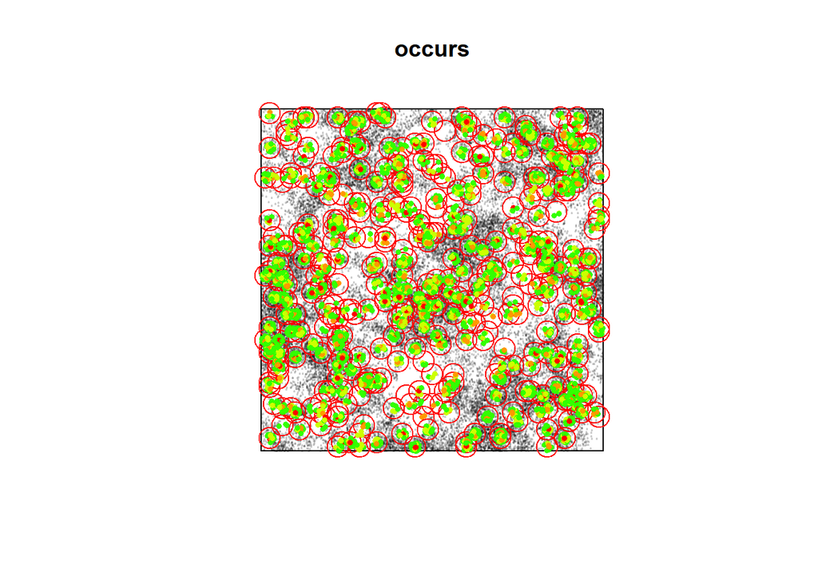

```r
plot(occurs, cex=0.2, asp=1)
points(sam_units, cex=2.5, pch=21, col='red', bg = NULL)

detrange <- 2.5 #determine the detection range of the transect

for (i in 1:400) {
  d <- point_samp$distance[,i]
  msk <- !is.na(d)
  col <- as.integer(cut(d[msk], seq(0, detrange, length.out=5)))
  points(occurs[msk,], pch=16, cex=0.6, col=rainbow(10)[col])
}
```

To visualize better, we make a new figure with a zoom on a specific region of the study area.

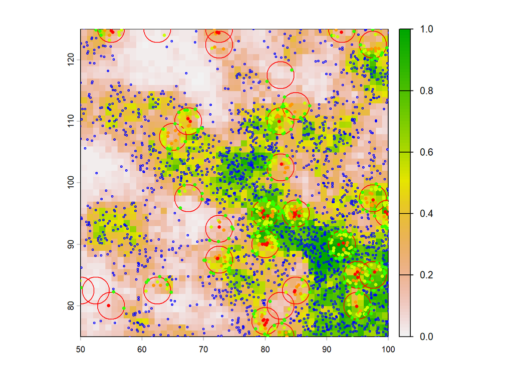

```r
ampl <- terra::ext(50, 100, 75, 125)
zoom(LAM_lgt_R, ampl, col= cols)
points(occurs, cex=0.4, asp=1, col = "blue")

points(sam_units, cex=5, pch=21, col='red', bg = NULL)
for (i in 1:400) {
  d <- point_samp$distance[,i]
  msk <- !is.na(d)
  col <- as.integer(cut(d[msk], seq(0, detrange, length.out=5)))
  points(occurs[msk,], pch=16, cex=0.6, col=rainbow(10)[col])
}
```

#### 5.2.2 Transect Sampling Method

```r
#pass the occurrences to dataframe
occus <- data.frame(occurs$x, occurs$y)

ns <- 200 #determine the number of samples
sampling <- randomSamp(ns, c(0,200), c(0,200), 10) #choose these samples inside a grid

tlength <- 5 #determine the legth of the transect
detrange <- 2.5 #determine the detection range of the transect

#Obtain the individual locations (with euclidean distance) for all the sampled transects used (sam_units)
transect_samp <- transectSample(sites = sampling, occ = occus, tlen = tlength, drng = detrange)
```

Once we have these matrix with the individuals detected per sampled point and their distances, we can do the same thing as we did with fixed points, save all this information in a data frame with the occurrence ID, the survey ID, and the distance of the detection. As well as being used for distance sampling models or hierarchical models.

```r
# Get row (occurrence) and column (site) indices with non-NA distances
dist_mat <- transect_samp$distance
idx <- which(!is.na(dist_mat), arr.ind = TRUE)

clear_df <- data.frame(
  occurrences = idx[, 1],        # row index = occurrence ID
  sample_id   = idx[, 2],        # col index = site ID
  distance    = dist_mat[idx]    # distance value
)

head(clear_df, 10)
```

|  | occurrences | sample_id | distance |
| --- | --- | --- | --- |
| 1 | 401 | 1 | 0.65407150 |
| 2 | 1063 | 1 | 0.80698543 |
| 3 | 1909 | 1 | 2.23953222 |
| 4 | 3673 | 1 | 0.19647269 |
| 5 | 3763 | 1 | 2.00101976 |
| 6 | 4268 | 1 | 1.15855496 |
| 7 | 4411 | 1 | 1.17099732 |
| 8 | 5826 | 1 | 0.83612322 |
| 9 | 10859 | 1 | 2.05931622 |
| 10 | 12959 | 1 | 0.04510314 |

We can also obtain the data frame containing the number of animals detected per sampling unit for this type of sampling procedure. By considering the `countOcc()` function, to which, in this case, the result of the `transectSample()` function is passed directly.

```r
tABN_samp <- countOcc(dmat = transect_samp$distance)
head(tABN_samp)
```

|  | site_ID | count |
| --- | --- | --- |
| 1 | 1 | 17 |
| 2 | 2 | 27 |
| 3 | 3 | 8 |
| 4 | 4 | 28 |
| 5 | 5 | 8 |
| 6 | 6 | 55 |

Here we present the figure to better understand what kind of data we are collecting. First, the entire study area, with the sampled transects (black lines), surrounded by the detection area (dashed line squares) and the individuals detected with a color pattern based on the euclidean distance from the orthogonal distance from the transect.

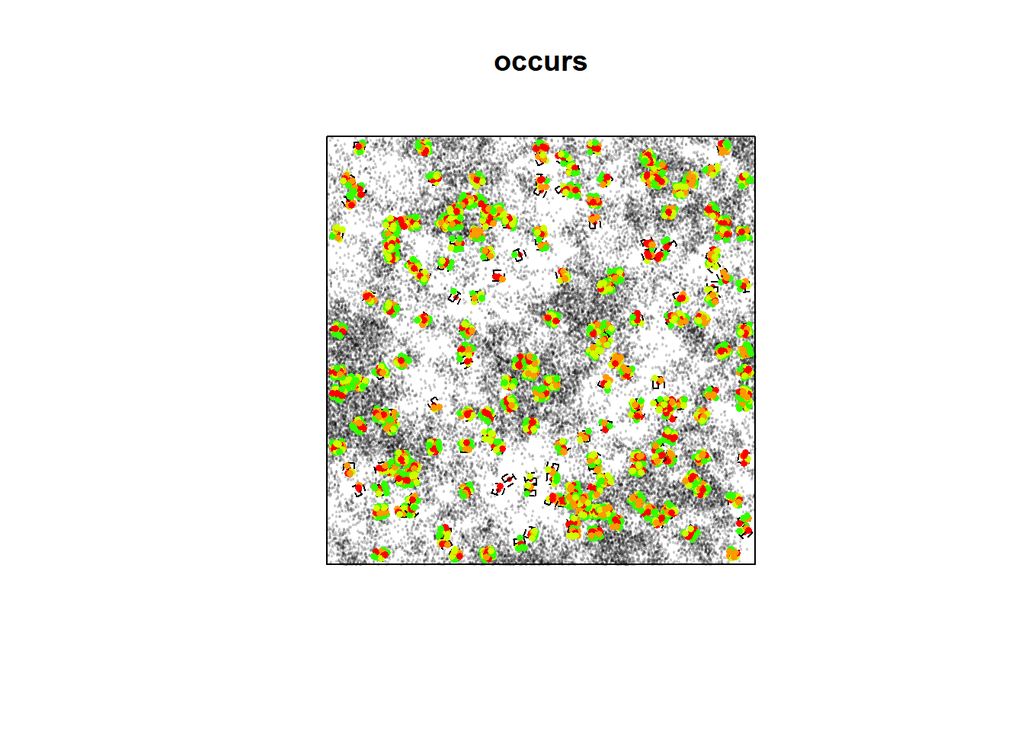

```r
plot(occurs, cex=0.2, asp=1)
points(sampling, cex=0.5, pch=16, col='red')

for (i in 1:ns) {
  pnts <- transect_samp$transect
  lines(pnts$x[i, c(2,5)], pnts$y[i, c(2,5)])
  polygon(pnts$x[i,], pnts$y[i,], lty=2)

  d <- transect_samp$distance[,i]
  msk <- !is.na(d)
  col <- as.integer(cut(d[msk], seq(0, detrange, length.out=5)))
  points(occurs[msk,], pch=16, cex=0.6, col=rainbow(10)[col])
}
```

Secondly, the figure with zoom, to visualize better.

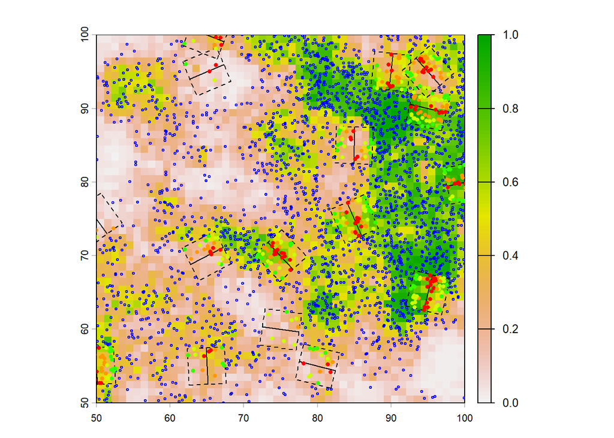

```r
ampl <- terra::ext(50, 100, 50, 100)
zoom(LAM_lgt_R, ampl, col= cols)
points(occurs, cex=0.4, asp=1, col = "blue")
for (i in 1:ns) {
  pnts <- transect_samp$transect
  lines(pnts$x[i, c(2,5)], pnts$y[i, c(2,5)])
  polygon(pnts$x[i,], pnts$y[i,], lty=2)

  d <- transect_samp$distance[,i]
  msk <- !is.na(d)
  col <- as.integer(cut(d[msk], seq(0, detrange, length.out=5)))
  points(occurs[msk,], pch=16, cex=0.6, col=rainbow(10)[col])
}
```

### 5.3 Transform abundance into presence/absence data

Not always we are interested in obtaining counts, we could prefer or need presence/absence data, or detections considering imperfect detections. In this section, we present the function `abundance2pres()`. With this function it is possible to transform the abundance values obtained in the previous sections to detections (detected/not-detected binomial value per sampled unit). The functions takes into account the imperfect detection per individual, so higher the number of individuals per sampled unit, higher the probability that detect at least one individual on the sampled unit. For this example, we will use the abundance values obtained on the *5.2.1 section*.

```r
abun <- pABN_samp #Abundance values dataset used as initial dataframe
ipd <- 0.5 #Probability of individual detection

sample_prove <- abundance2pres(abun, ipd)

#see the number of sampling units without and with detections
#(0 = no-detections, 1 = detections)
table(sample_prove$occurrences)
```

```
  0   1
 11 389
```

Once we have these transformation done per sampled unit, we save this information in a data frame with the coordinates, the survey ID (the sampled unit), the abundance value (count of individual presents on the sampled unit), and the occurrence values (binomial value of detection or not-detection of the species on the sampled unit).

```r
sampling_units <- data.frame(cbind(x = sam_units$x,
                                   y = sam_units$y,
                                   sampleID = sample_prove$sampleID,
                                   abundance = sample_prove$abundance,
                                   occurrences = sample_prove$occurrences))
head(sampling_units, 10)
```

|  | x | y | sampleID | abundance | occurrences |
| --- | --- | --- | --- | --- | --- |
| 1 | 117.5 | 195.0 | 1 | 18 | 1 |
| 2 | 10.0 | 52.5 | 2 | 17 | 1 |
| 3 | 12.5 | 15.0 | 3 | 3 | 1 |
| 4 | 82.5 | 157.5 | 4 | 6 | 1 |
| 5 | 180.0 | 190.0 | 5 | 2 | 1 |
| 6 | 35.0 | 112.5 | 6 | 5 | 1 |
| 7 | 182.5 | 105.0 | 7 | 38 | 1 |
| 8 | 185.0 | 190.0 | 8 | 9 | 1 |
| 9 | 175.0 | 172.5 | 9 | 29 | 1 |
| 10 | 182.5 | 32.5 | 10 | 50 | 1 |

Now, We can visualize each type of data collected showing the total area of study. To compare easily the differences between them.

First, we visualize the abundance values.

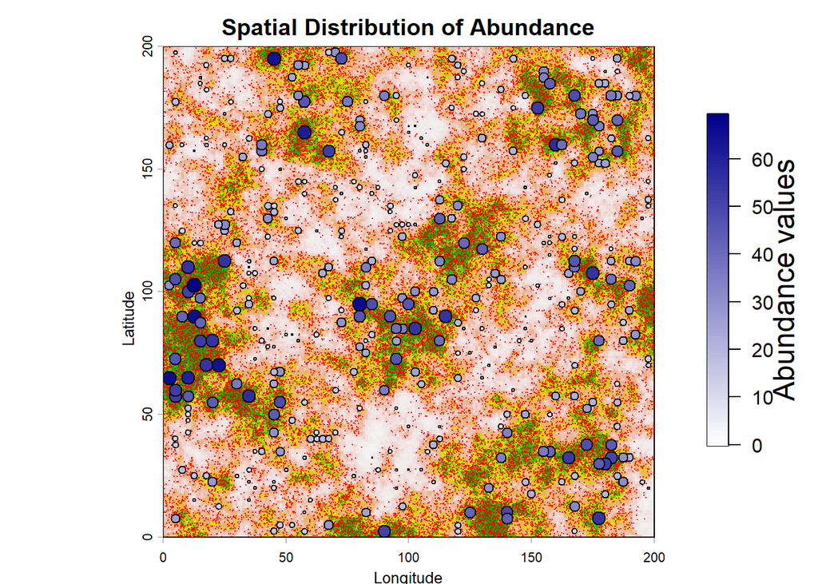

```r
# Configuration of the plotting window
par(mfrow = c(1,1))  # Adjust margins
plot(LAM_lgt_R,
     main = "Spatial Distribution of Abundance",
     xlab = "Longitude",
     ylab = "Latitude",
     legend = FALSE,
     col = cols)  # Background raster

# Red points for real locations
points(occurs, col = "red", pch = 16, cex = 0.05)

# Create color palette (white to dark blue)
pal <- colorRampPalette(c("white", "darkblue"))

# Adjust point sizes based on abundance
point_sizes <- sqrt(sampling_units$abundance + 1) * 0.2 # Scale size proportionally

# Assign colors based on abundance values
points(sampling_units,
       col = "black",
       bg = pal(100)[cut(sampling_units$abundance, breaks = 100, labels = FALSE)],
       cex = point_sizes,
       pch = 21)

# Add color bar for abundance
colorTable <- designer.colors(100, c("white", "darkblue"))
image.plot(add = TRUE, legend.only = TRUE,
           zlim = range(sampling_units$abundance, na.rm = TRUE),
           col = colorTable,
           legend.args = list(text = "Abundance values",
                              col = "black", cex = 1.5, side = 4, line = 2))
```

Next, we visualize the detection, non-detection values.

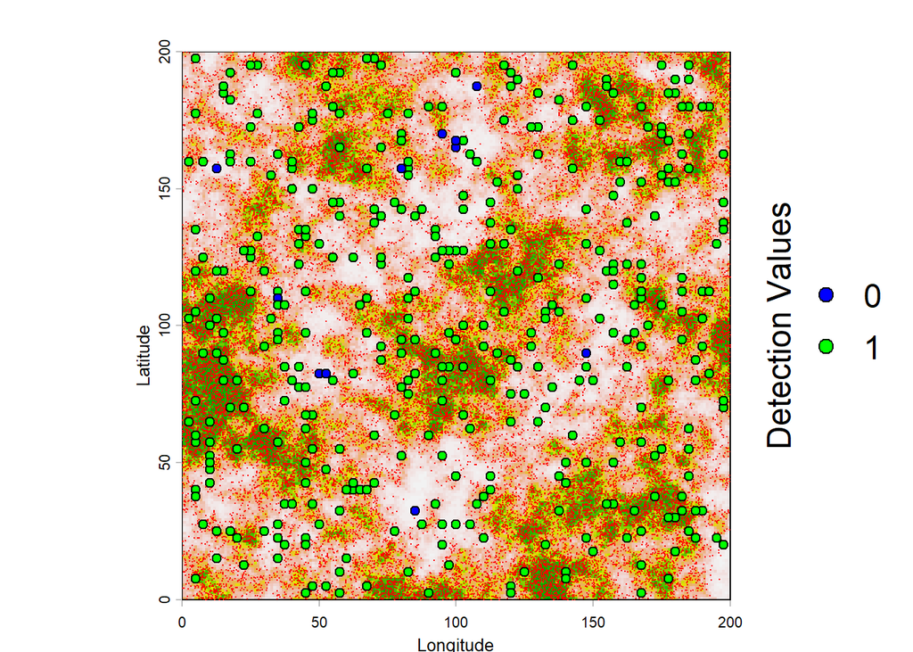

```r
par(mar = c(5, 5, 4, 6))
plot(LAM_lgt_R,
     xlab = "Longitude",
     ylab = "Latitude",
     legend = FALSE,
     col = cols)

points(occurs, col = "red", pch = 16, cex = 0.05)

# Define specific colors for categorical values (detected not-detected)
category_colors <- c("blue", "green")  # blue for 0, green for 1
names(category_colors) <- c(0, 1)  # Associate colors with occurrences values

# Assign colors based on occurrence values
points(sampling_units, col = "black",
       bg = category_colors[as.character(sampling_units$occurrences)],
       pch = 21)

# Add the legend with categoric values
legend("topright", inset = c(-0.05, 0.35),
       legend = c("0", "1"),
       col = "black", pt.bg = category_colors,
       cex = 1.5, bty = "n", pch = 21, xpd = TRUE)

mtext('Detection Values', cex = 1.5, side = 4, line = 0.5)
```

## 6. Export the simulated data

In this section, we will show you how to save and export the various layers and data sets that have been created in this vignette. But before running the following code, make sure where is your working directory using `here()`. If you want to change, modify with `setwd()`.

### 6.1 Save Sampled data

We start saving the data frame with all the information obtained in the samples (coordinates, occurrence values (detections), abundance values, sample ID). For this data frame as well as the other elements we have been creating, we will create folders to organize them. All of this is made easier by the `file.path()`, `dir.exist()`, and `dir.create()` functions from the **base** package.

```r
#Create a folder for this layer
savepath <- file.path(here("Data_created"))
if (!dir.exists(savepath)) {
  dir.create(savepath, recursive=TRUE)
  print(paste("Creating directory", savepath))
} else {
  print("Directory already exists. Overwriting.")
}
```

```
[1] "Directory already exists. Overwriting."
```

```r
write.table(sampling_units, here('Data_created/sampling_units.csv'), row.names = FALSE, sep = ",")
```

But could be interesting save a database with only detections, because this type of format is used in some methodologies such as *Maxent*.

```r
final_data <- sampling_units[sampling_units$occurrences == 1,]
final_data <- data.frame(final_data[,c(1,2)])
h <- data.frame(ID = cbind(c(rep.int("Virtual_Species", nrow(final_data)))))
final_data <- list(ID=h, x=final_data$x, y=final_data$y)
write.table(final_data, here("Data_created/occ_virtualspecies.csv"), row.names = FALSE, sep = ",")
```

### 6.2 Save Suitability layer

We continue saving the suitability layer, which has been used to determine the distribution of the individuals.

```r
terra::writeRaster(LAM_lgt_R, here("Data_created/Expected_abundance.asc"), NAflag = -9999, overwrite=TRUE)
```

### 6.3 Save BIOS layers for the analysis

Previously we have standardized the BIOS layers, now we save all of them changed to a range with positive values (keeping all the values >0), avoiding negative and zero values, that could produce problems in softwares like *Maxent*.

```r
bv_post <-  bv_std + abs(min(bv_std)) + 1

#Create a folder for this layers
savepath <- file.path(here("Data_created/BIOS"))
if (!dir.exists(savepath)) {
  dir.create(savepath, recursive=TRUE)
  print(paste("Creating directory", savepath))
} else {
  print(paste("Directory already exists. Overwriting."))
}
```

```
[1] "Directory already exists. Overwriting."
```

```r
#Save all the BIO rasters with format ASCII
for (i in 1:19) {
  route_rst<-paste("Data_created/BIOS/BIO",i,"_post.asc", sep="")
  writeRaster(bv_post[[i]], here(route_rst), overwrite= TRUE)
}
```

And we save the BIOS layers at lower resolution, with the same process.

We save the layers at 20x20 units resolution.

```r
bv_post <-  bv20_std + abs(min(bv20_std)) + 1

#Create a folder for this layers
savepath <- file.path(here("Data_created/20BIOS"))
if (!dir.exists(savepath)) {
  dir.create(savepath, recursive=TRUE)
  print(paste("Creating directory", savepath))
} else {
  print(paste("Directory already exists. Overwriting."))
}
```

```
[1] "Directory already exists. Overwriting."
```

```r
#Save all the BIO rasters with format ASCII
for (i in 1:19) {
  route_rst<-paste("Data_created/20BIOS/20BIO",i,"_post.asc", sep="")
  writeRaster(bv_post[[i]], here(route_rst), overwrite= TRUE)
}
```

And continue with the layers at 40x40 units resolution.

```r
bv_post <-  bv40_std + abs(min(bv40_std)) + 1

#Create a folder for this layers
savepath <- file.path(here("Data_created/40BIOS"))
if (!dir.exists(savepath)) {
  dir.create(savepath, recursive=TRUE)
  print(paste("Creating directory", savepath))
} else {
  print(paste("Directory already exists. Overwriting."))
}
```

```
[1] "Directory already exists. Overwriting."
```

```r
#Save all the BIO rasters with format ASCII
for (i in 1:19) {
  route_rst<-paste("Data_created/40BIOS/40BIO",i,"_post.asc", sep="")
  writeRaster(bv_post[[i]], here(route_rst), overwrite= TRUE)
}
```

### 6.4 Save Vegetation layers

We do the same as in the previous section with the vegetation raster layers.

Original high resolution layer.

```r
#Create a folder for this layer
savepath <- file.path(here("Data_created/VEG"))
if (!dir.exists(savepath)) {
  dir.create(savepath, recursive=TRUE)
  print(paste("Creating directory", savepath))
} else {
  print(paste("Directory already exists. Overwriting."))
}
```

```
[1] "Directory already exists. Overwriting."
```

```r
#Save the VEG raster with format ASCII
writeRaster(vegt_std, here("Data_created/VEG/VEGETATION.asc"), overwrite=TRUE)
```

Layer at 20x20 units resolution.

```r
#Create a folder for this layer
savepath <- file.path(here("Data_created/20VEG"))
if (!dir.exists(savepath)) {
  dir.create(savepath, recursive=TRUE)
  print(paste("Creating directory", savepath))
} else {
  print(paste("Directory already exists. Overwriting."))
}
```

```
[1] "Directory already exists. Overwriting."
```

```r
#Save the VEG raster with format ASCII
writeRaster(vegt20_std, here("Data_created/20VEG/20VEGETATION.asc"), overwrite=TRUE)
```

Layer at 40x40 units resolution.

```r
#Create a folder for this layer
savepath <- file.path(here("Data_created/40VEG"))
if (!dir.exists(savepath)) {
  dir.create(savepath, recursive=TRUE)
  print(paste("Creating directory", savepath))
} else {
  print(paste("Directory already exists. Overwriting."))
}
```

```
[1] "Directory already exists. Overwriting."
```

```r
#Save the VEG raster with format ASCII
writeRaster(vegt40_std, here("Data_created/40VEG/40VEGETATION.asc"), overwrite=TRUE)
```

### 6.5 Save original climate variable (Temperature and Precipitation)

And finally, we do the same with the layers related with climate (temperature and precipitation).

```r
#Create a folder for this layer
savepath <- file.path(here("Data_created/CLIM"))
if (!dir.exists(savepath)) {
  dir.create(savepath, recursive=TRUE)
  print(paste("Creating directory", savepath))
} else {
  print(paste("Directory already exists. Overwriting."))
}
```

```
[1] "Directory already exists. Overwriting."
```

```r
#Save the VEG raster with format ASCII
writeRaster(clim_std$temp, here("Data_created/CLIM/TEMEPRATURE.asc"), overwrite=TRUE)
writeRaster(clim_std$prec, here("Data_created/CLIM/PRECIPITATION.asc"), overwrite=TRUE)
```

## 7. Creating a dendrogram. Correlation between covariates

And to conclude this *vignette*, here is an example of how to select predictor variables. Because it is common that we are interested in different covariates to consider in our models, but these covariates could be correlated, and at high levels this could be a problem. Here we present one way to visualize this correlation and detect clusters of correlation (to choose only one per cluster; visualized as blue boxes). In this case, we use the BIOS that we have created (because we know that they are correlated), to visualize the correlation and choose those that are of interest and with low level of correlation between them. In this case, we consider the limit a correlation value of 0.8 (or a dissimilarity higher than 0.2, employed in the dendogram). All this thanks to `as.dendrogram()` function of the **stats** package.

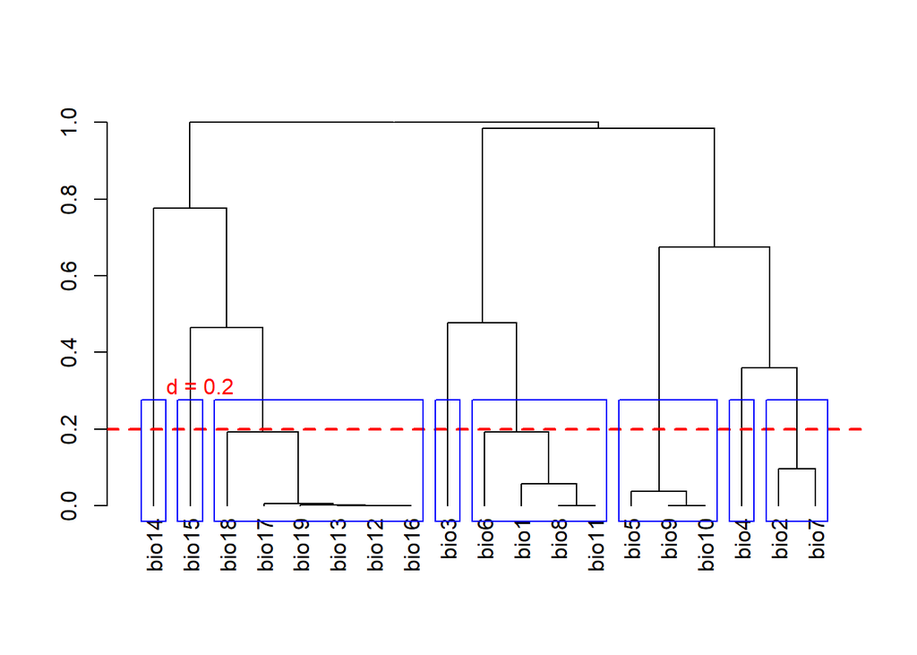

```r
bv_post <-  bv_std + abs(min(bv_std)) + 1
bv_post_df <- as.data.frame(bv_post) #save a data.frame of the variables in columns
bv_post_df <- na.omit(bv_post_df) #eliminate NAs
library(corrplot)
BIOS_cor <- cor(bv_post_df, use = "pairwise.complete.obs") #create a correlation matrix
BIOS_disim <- 1 - abs(BIOS_cor) #change correlation values to dissimilarity values
BIOS_dist <- as.dist(BIOS_disim) #consider the value as distance
dendrogram <- as.dendrogram(hclust(BIOS_dist, method ="complete")) #create the dendogram
plot(dendrogram) #visualize

#Add the limit of dissimilarity
abline(h = 0.2, col = "red", lwd = 2, lty = 2)
text(x = 1, y = 0.31, labels = "d = 0.2", col = "red", pos = 4)

#Identify the clusters with lower dissimilarity
rect.hclust(hclust(BIOS_dist, method ="complete"), h = 0.2, border = "blue")
```